# STAT1003 Introduction to Data Science

Solution: Test 2, Practice Question

# Instructions

1. Save this file to `I:\STAT1003` and rename it by adding your student ID to the beginning of the file name;
2. Download and save the file `STAT1003Test2.RData` along with any image files into the same directory;
3. Carry out all of your work in this Rmarkdown file;
4. **Save your work frequently!**
5. When you are finished, upload this Rmarkdown file and the resulting ‘knitted’ .docx file to the Assessments section from which you downloaded the files.
6. Total number of marks: **20**

# Predicting Fuel Efficiency of Cars (20 marks)

The US Environmental Protection Agency lists different estimates of the fuel economy (`FE`, in mpg) of passenger cars and trucks sold in the US. For each vehicle, various characteristics are recorded, such as the engine displacement or the number of cylinders. Your task, as a vacation student at the EPA, is to construct a linear regression model for fuel efficiency using data from 2010 (`Cars2010`) and then use it to predict fuel efficiency of cars in the 2011 model year (`Cars2011`). These data frames are contained in the file `STAT1003Test2.RData`.

```r
# Load the data here
print(load("STAT1003Test2.RData"))
```

```
[1] "Cars2010" "Cars2011"
```

1. Produce two plots that you might use to explore the dataset, but before you do, make sure you understand the structure of the data. Comment on any patterns you see in the plots you have produced. (5 marks)

As part of any exploratory data analysis, it’s always useful to get to know the data, starting with knowing what variables are included in the dataset, to numerical and then graphical summaries. Below, I do this for the data frame `Cars2010` (the training set) only, but it would be essential to do this with the test set (`Cars2011`) as well.

First, some simple getting-to-know the data stuff:

```r
dim(Cars2010)
```

```
[1] 1107   10
```

```r
colnames(Cars2010)
```

```
 [1] "EngDispl"            "NumCyl"              "FE"
 [4] "NumGears"            "TransLockup"         "TransCreeperGear"
 [7] "IntakeValvePerCyl"   "ExhaustValvesPerCyl" "VarValveTiming"
[10] "VarValveLift"
```

```r
summary(Cars2010)
```

```
    EngDispl         NumCyl             FE           NumGears
 Min.   :1.000   Min.   : 2.000   Min.   :17.50   Min.   :1.000
 1st Qu.:2.400   1st Qu.: 4.000   1st Qu.:29.09   1st Qu.:5.000
 Median :3.500   Median : 6.000   Median :34.51   Median :6.000
 Mean   :3.507   Mean   : 5.971   Mean   :34.71   Mean   :5.268
 3rd Qu.:4.300   3rd Qu.: 8.000   3rd Qu.:39.20   3rd Qu.:6.000
 Max.   :8.400   Max.   :16.000   Max.   :69.64   Max.   :8.000
  TransLockup     TransCreeperGear  IntakeValvePerCyl ExhaustValvesPerCyl
 Min.   :0.0000   Min.   :0.00000   Min.   :0.000     Min.   :0.000
 1st Qu.:0.0000   1st Qu.:0.00000   1st Qu.:2.000     1st Qu.:2.000
 Median :1.0000   Median :0.00000   Median :2.000     Median :2.000
 Mean   :0.6802   Mean   :0.04878   Mean   :1.862     Mean   :1.837
 3rd Qu.:1.0000   3rd Qu.:0.00000   3rd Qu.:2.000     3rd Qu.:2.000
 Max.   :1.0000   Max.   :1.00000   Max.   :3.000     Max.   :2.000
 VarValveTiming    VarValveLift
 Min.   :0.0000   Min.   :0.0000
 1st Qu.:1.0000   1st Qu.:0.0000
 Median :1.0000   Median :0.0000
 Mean   :0.8229   Mean   :0.1671
 3rd Qu.:1.0000   3rd Qu.:0.0000
 Max.   :1.0000   Max.   :1.0000
```

```r
require(Hmisc)  # contains the function 'describe'
describe(Cars2010)
```

```
Cars2010

 10  Variables      1107  Observations
---------------------------------------------------------------------------
EngDispl
       n  missing distinct     Info     Mean      Gmd      .05      .10
    1107        0       49    0.996    3.507    1.462      1.8      2.0
     .25      .50      .75      .90      .95
     2.4      3.5      4.3      5.5      6.0

lowest : 1.0 1.3 1.5 1.6 1.8, highest: 6.7 6.8 7.0 8.0 8.4
---------------------------------------------------------------------------
NumCyl
       n  missing distinct     Info     Mean      Gmd
    1107        0        9    0.905    5.971    1.987

Value          2     3     4     5     6     8    10    12    16
Frequency      2     2   364    42   402   248    15    31     1
Proportion 0.002 0.002 0.329 0.038 0.363 0.224 0.014 0.028 0.001
---------------------------------------------------------------------------
FE
       n  missing distinct     Info     Mean      Gmd      .05      .10
    1107        0      585        1    34.71    8.353    23.81    25.20
     .25      .50      .75      .90      .95
   29.09    34.51    39.20    44.47    47.68

lowest : 17.5000 17.8000 19.7000 19.9000 20.1000
highest: 60.1000 61.2000 62.2674 65.0000 69.6404
---------------------------------------------------------------------------
NumGears
       n  missing distinct     Info     Mean      Gmd
    1107        0        6    0.881    5.268    1.355

Value          1     4     5     6     7     8
Frequency     69   156   265   517    88    12
Proportion 0.062 0.141 0.239 0.467 0.079 0.011
---------------------------------------------------------------------------
TransLockup
       n  missing distinct     Info      Sum     Mean      Gmd
    1107        0        2    0.653      753   0.6802   0.4354
```

[output cut: 18 more lines]

```

Value          0     1     2
Frequency      2   176   929
Proportion 0.002 0.159 0.839
---------------------------------------------------------------------------
VarValveTiming
       n  missing distinct     Info      Sum     Mean      Gmd
    1107        0        2    0.437      911   0.8229   0.2917

---------------------------------------------------------------------------
VarValveLift
       n  missing distinct     Info      Sum     Mean      Gmd
    1107        0        2    0.418      185   0.1671   0.2786

---------------------------------------------------------------------------
```

**Summary**: All the variables are numeric, but some of them occur at discrete levels only.

Plots that it would be useful to produce include a plotting the results of the ‘describe’ function above (though it doesn’t show all the variables), a ‘pairs’ plot (though as we’ll see below, it can be difficult to interpret with this many variables), plots of `FE` against each of the other variables, and so on.

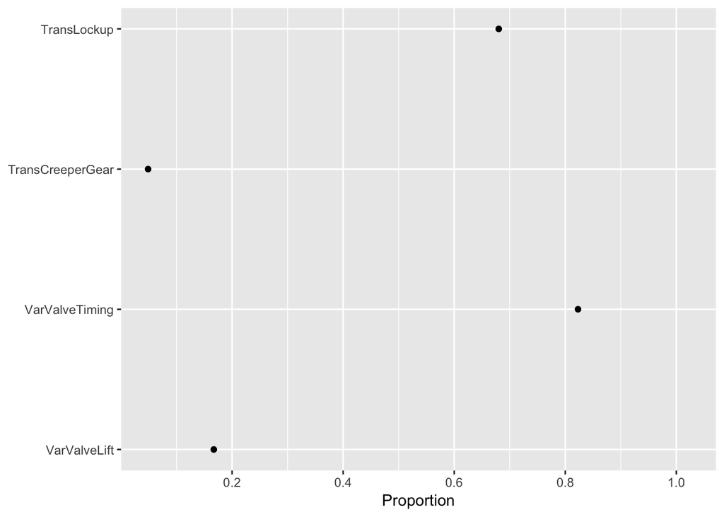

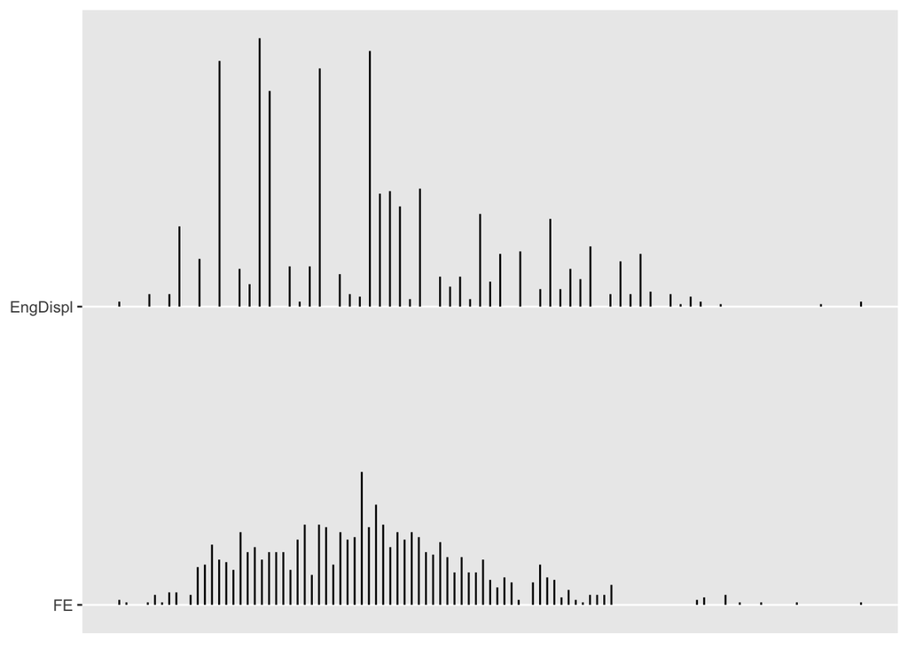

```r
# Plot 1
plot(describe(Cars2010))
```

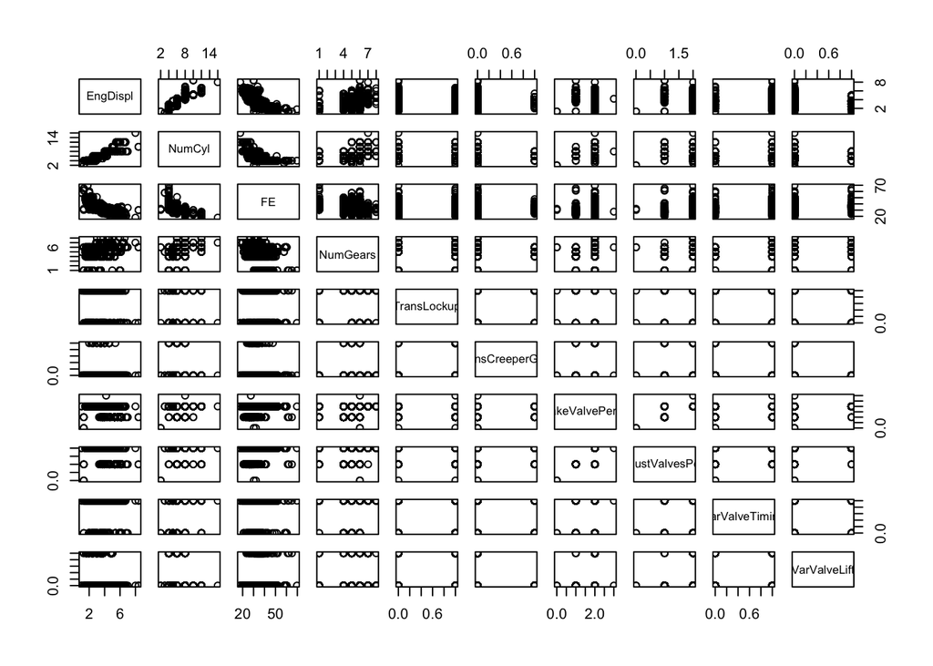

```r
# Plot 2
pairs(Cars2010)
```

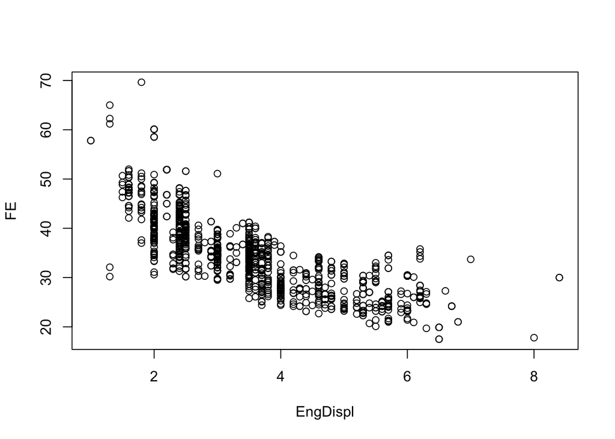

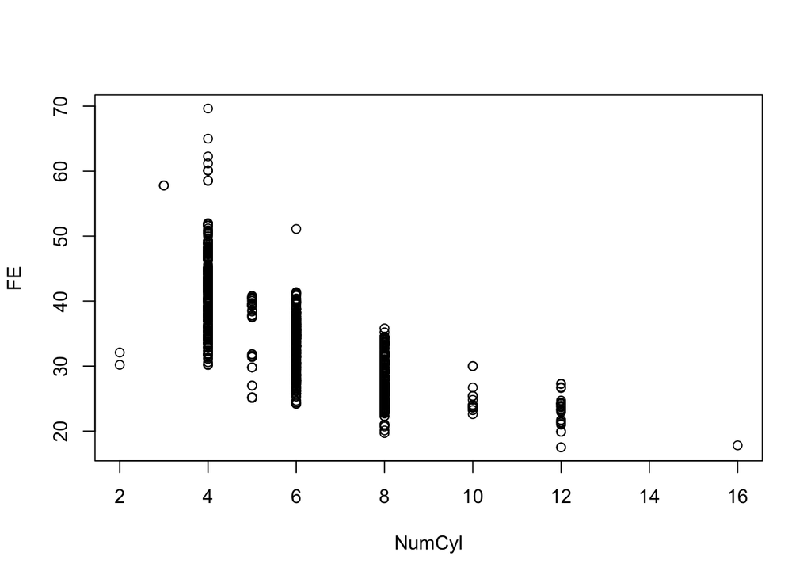

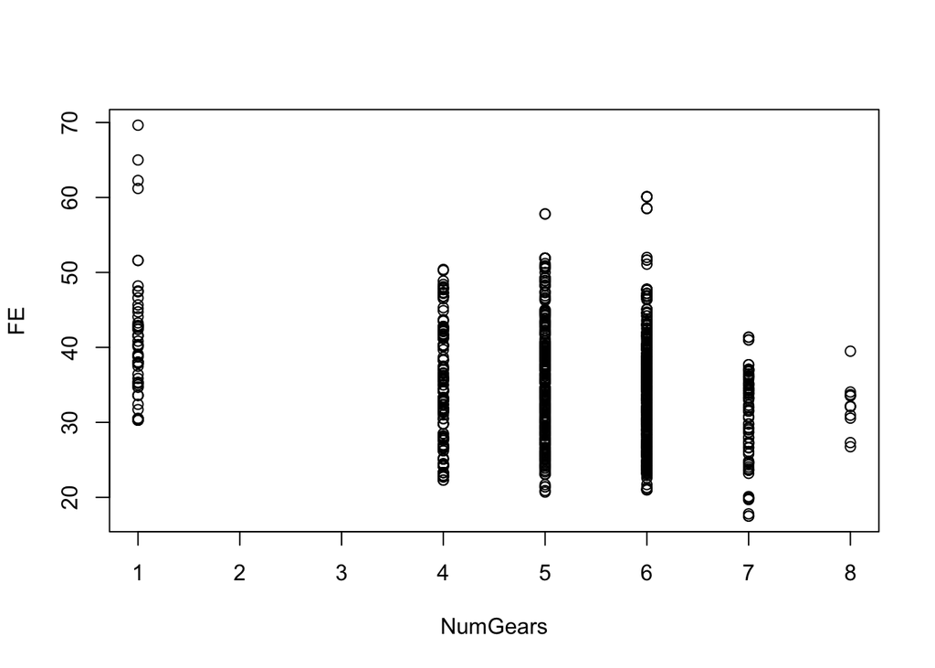

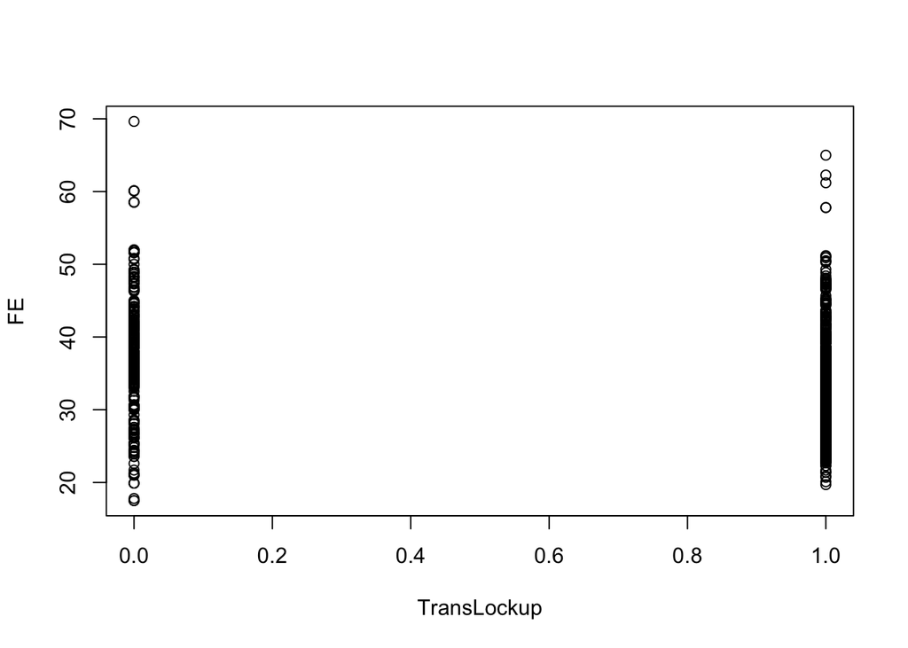

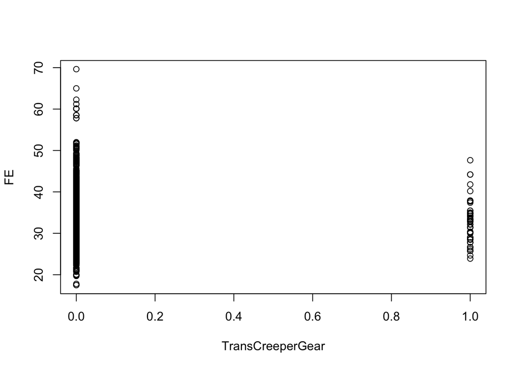

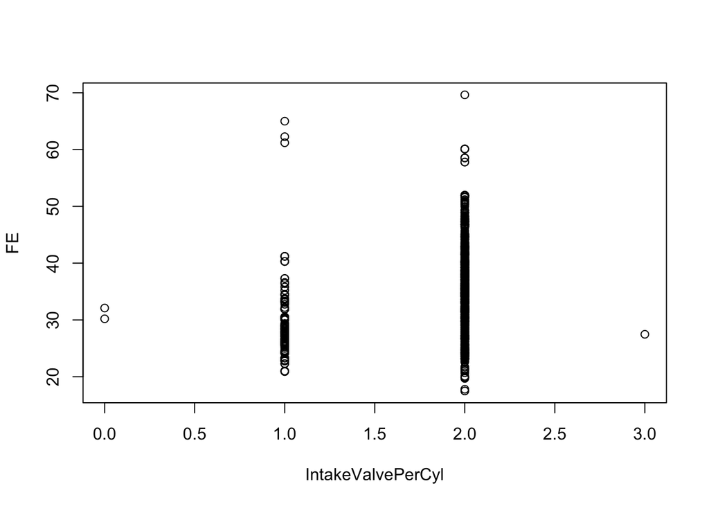

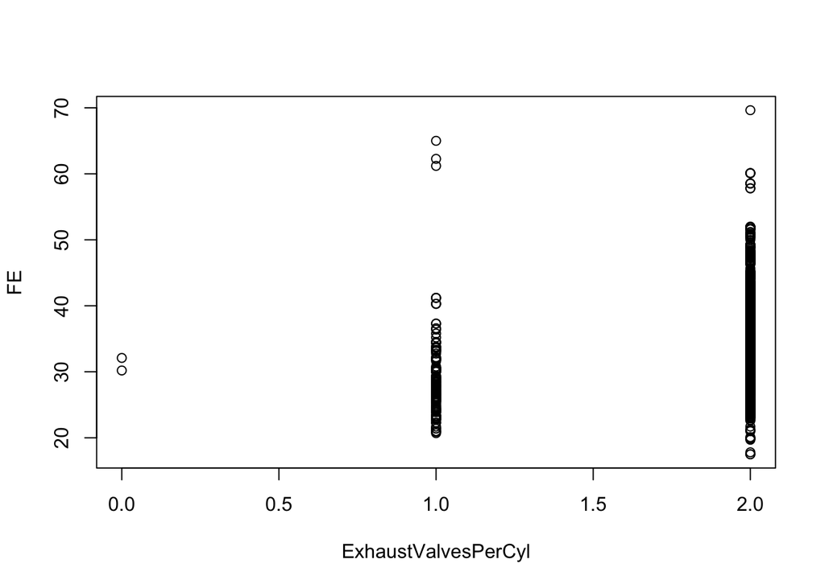

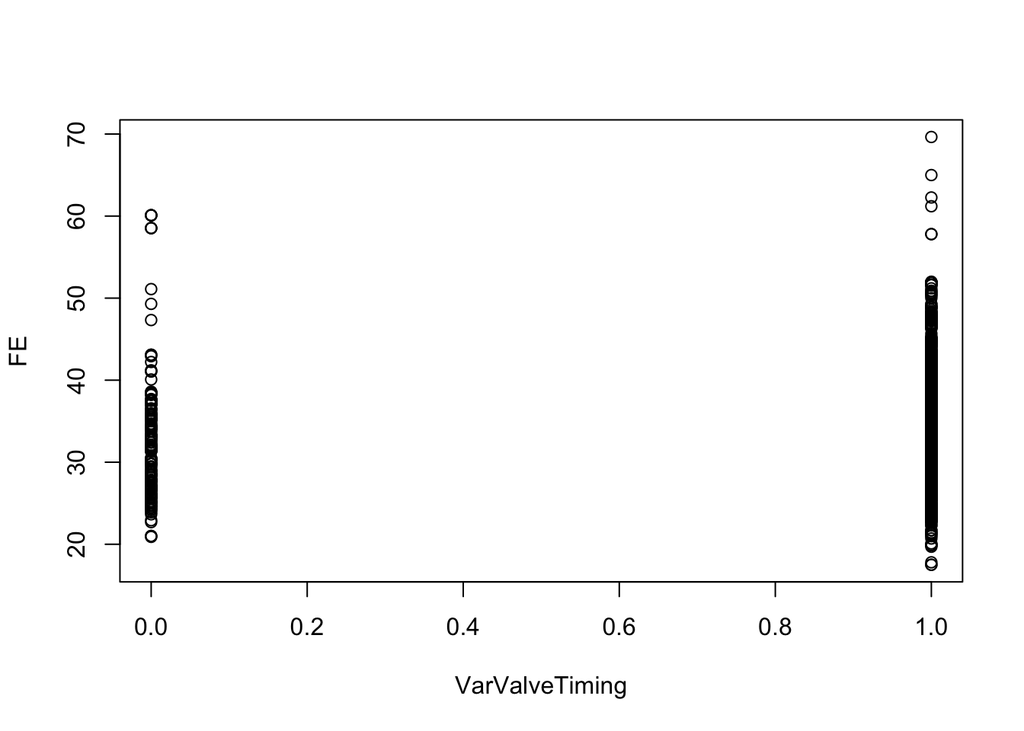

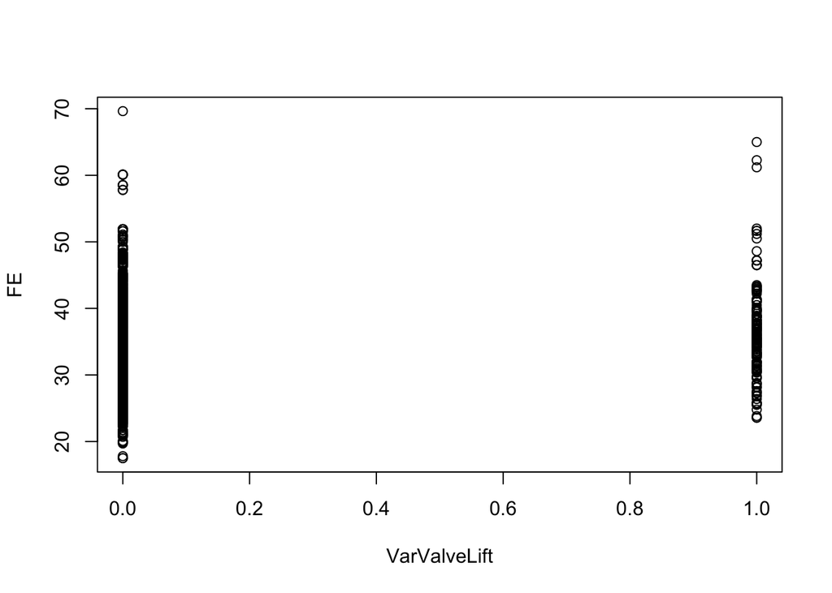

```r
# Plot 3
plot(FE ~ ., data = Cars2010)
```

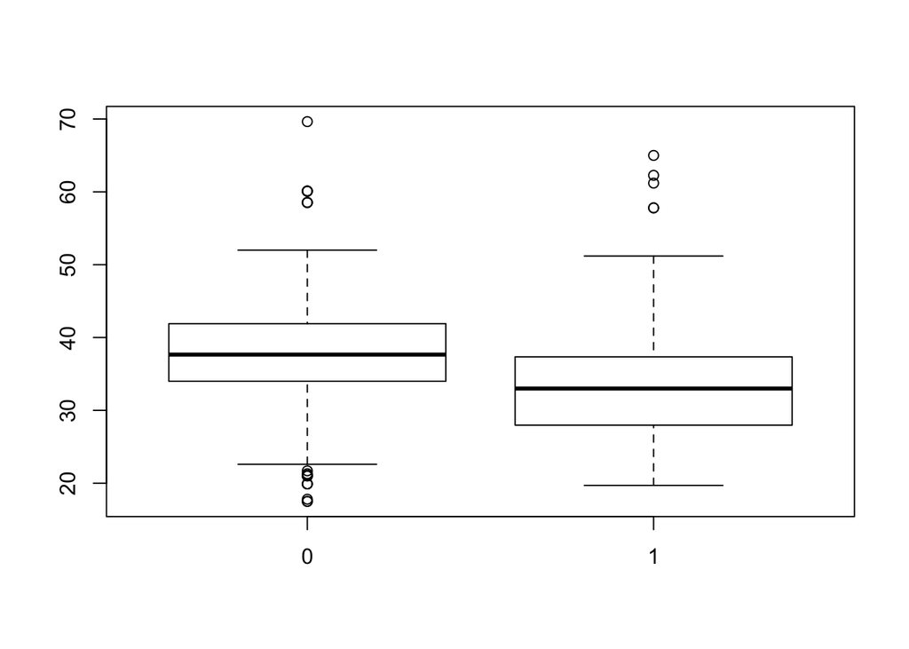

```r
# Given that some of the variables occur at discrete levels, we could even
# produce boxplots of FE against these variables instead, e.g.,
boxplot(FE ~ TransLockup, data = Cars2010)
```

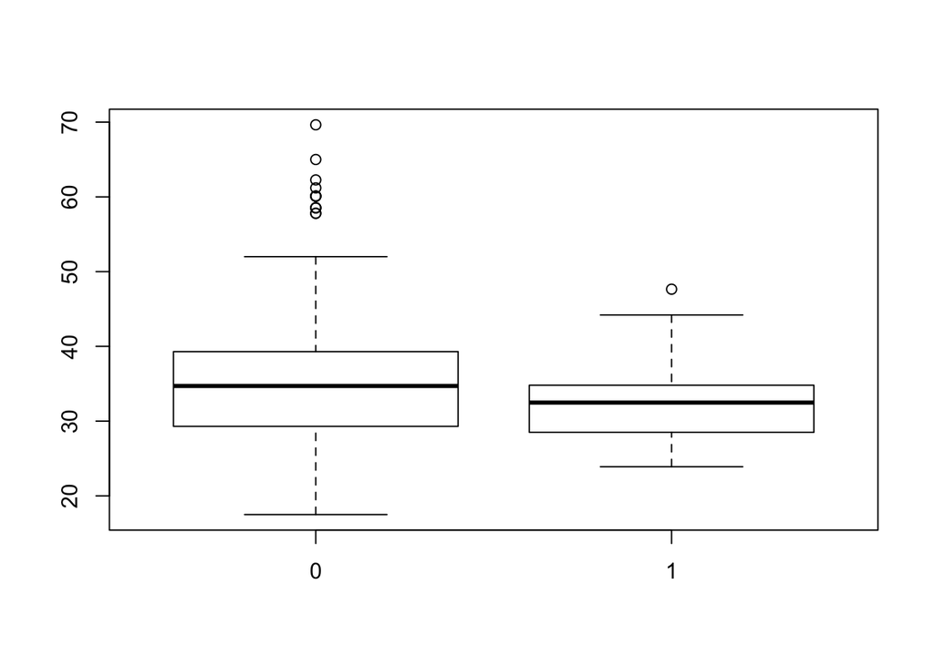

```r
boxplot(FE ~ TransCreeperGear, data = Cars2010)
```

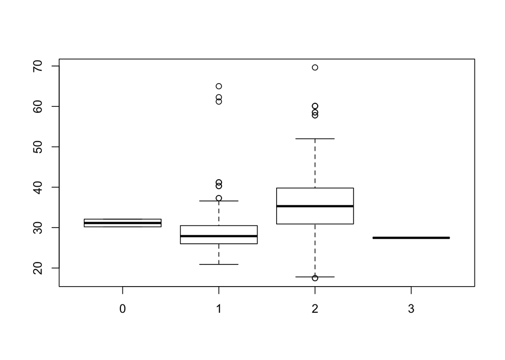

```r
boxplot(FE ~ IntakeValvePerCyl, data = Cars2010)
```

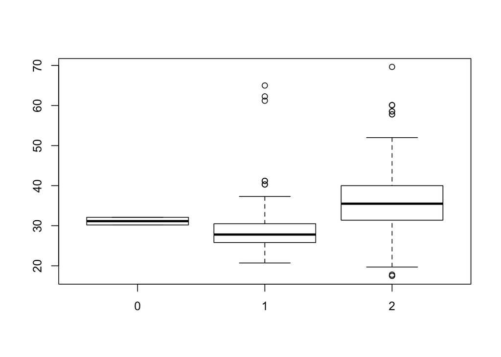

```r
boxplot(FE ~ ExhaustValvesPerCyl, data = Cars2010)
```

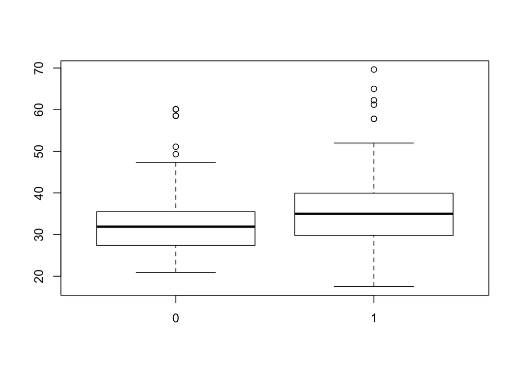

```r
boxplot(FE ~ VarValveTiming, data = Cars2010)
```

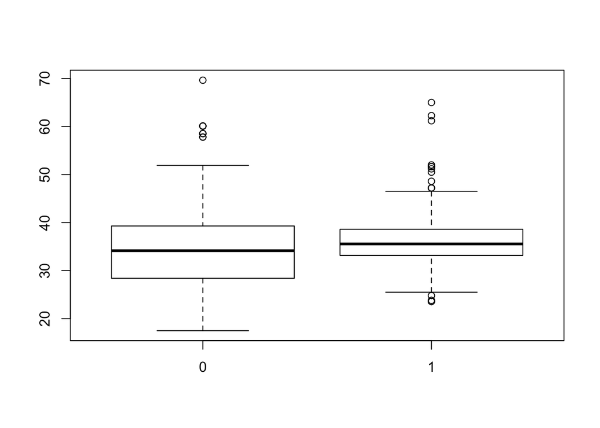

```r
boxplot(FE ~ VarValveLift, data = Cars2010)
```

Comments: Not surprisingly, `FE` has a negative relationship with engine displacement and the number of cylinders, and this relationship appears slightly curvilinear. The other explanatory variables are either discrete or categorical with two levels, so it is difficult to tell whether strong relationships exist. Boxplots show small differences between mean levels.

2. Fit a linear model for fuel efficiency using all the potential explanatory variables, and output a summary of the linear model object you have produced. (2 marks)

```r
#
lmall <- lm(FE ~ ., data = Cars2010)
summary(lmall)
```

```
Call:
lm(formula = FE ~ ., data = Cars2010)

Residuals:
     Min       1Q   Median       3Q      Max
-17.1153  -2.7142  -0.3535   2.4191  25.6521

Coefficients:
                    Estimate Std. Error t value Pr(>|t|)
(Intercept)          54.3472     1.0973  49.530  < 2e-16 ***
EngDispl             -3.8610     0.2805 -13.765  < 2e-16 ***
NumCyl               -0.4888     0.1845  -2.649  0.00819 **
NumGears             -0.1725     0.1065  -1.620  0.10555
TransLockup          -1.4450     0.3000  -4.817 1.66e-06 ***
TransCreeperGear     -0.9138     0.6681  -1.368  0.17167
IntakeValvePerCyl    -0.3737     0.9892  -0.378  0.70566
ExhaustValvesPerCyl  -1.1105     0.9598  -1.157  0.24752
VarValveTiming        1.6870     0.3796   4.444 9.71e-06 ***
VarValveLift          0.6235     0.3719   1.676  0.09393 .
---
Signif. codes:  0 '***' 0.001 '**' 0.01 '*' 0.05 '.' 0.1 ' ' 1

Residual standard error: 4.489 on 1097 degrees of freedom
Multiple R-squared:  0.6445,    Adjusted R-squared:  0.6415
F-statistic: 220.9 on 9 and 1097 DF,  p-value: < 2.2e-16
```

3. Naively, your manager suggests that you eliminate some variables based on their $p$-values in the summary output in b. and on your exploratory plots. Based on these naive criteria, which variables do you think ought to be retained in or eliminated from the model? Re-fit the model with only those variables you have decided to retain. (**If you do not know how to do that, push ahead with the full model.**) (4 marks)

```r
# There are lots of ways of fitting the smaller model, but one way is to use
# the function 'update' to update a model that has already been created:
lmsmall <- update(lmall, formula. = . ~ . - Numgears - TransCreeperGear - IntakeValvePerCyl -
    ExhaustValvesPerCyl - VarValveLift)
summary(lmsmall)
```

```
Call:
lm(formula = FE ~ EngDispl + NumCyl + NumGears + TransLockup +
    VarValveTiming, data = Cars2010)

Residuals:
     Min       1Q   Median       3Q      Max
-14.2298  -2.8242  -0.4507   2.3999  25.4351

Coefficients:
               Estimate Std. Error t value Pr(>|t|)
(Intercept)     51.6406     0.6745  76.557  < 2e-16 ***
EngDispl        -3.5137     0.2515 -13.972  < 2e-16 ***
NumCyl          -0.6073     0.1753  -3.464 0.000552 ***
NumGears        -0.2381     0.1025  -2.322 0.020415 *
TransLockup     -1.4857     0.2997  -4.957 8.29e-07 ***
VarValveTiming   1.5566     0.3625   4.294 1.91e-05 ***
---
Signif. codes:  0 '***' 0.001 '**' 0.01 '*' 0.05 '.' 0.1 ' ' 1

Residual standard error: 4.508 on 1101 degrees of freedom
Multiple R-squared:  0.6402,    Adjusted R-squared:  0.6386
F-statistic: 391.9 on 5 and 1101 DF,  p-value: < 2.2e-16
```

4. Output the ‘standard’ linear model diagnostics that *R* produces for the reduced model (or full model if you weren’t able to produce one in c.), and comment briefly on any patterns you see in the first three plots that might either support or throw into doubt the validity of a linear model for fuel efficiency. (4 marks)

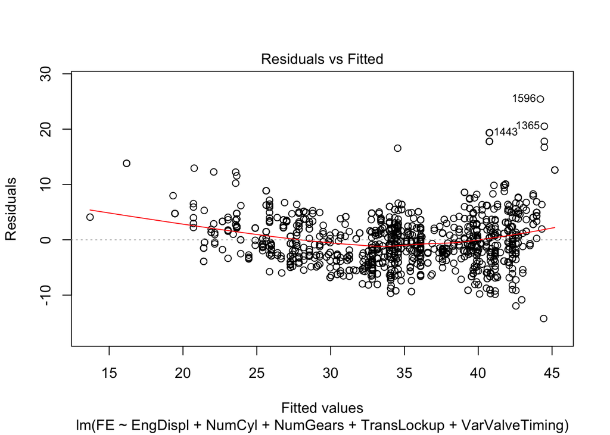

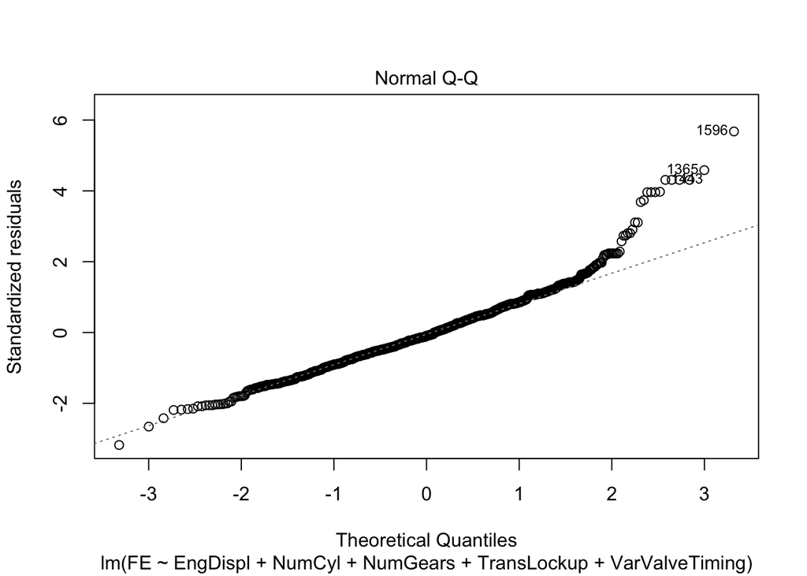

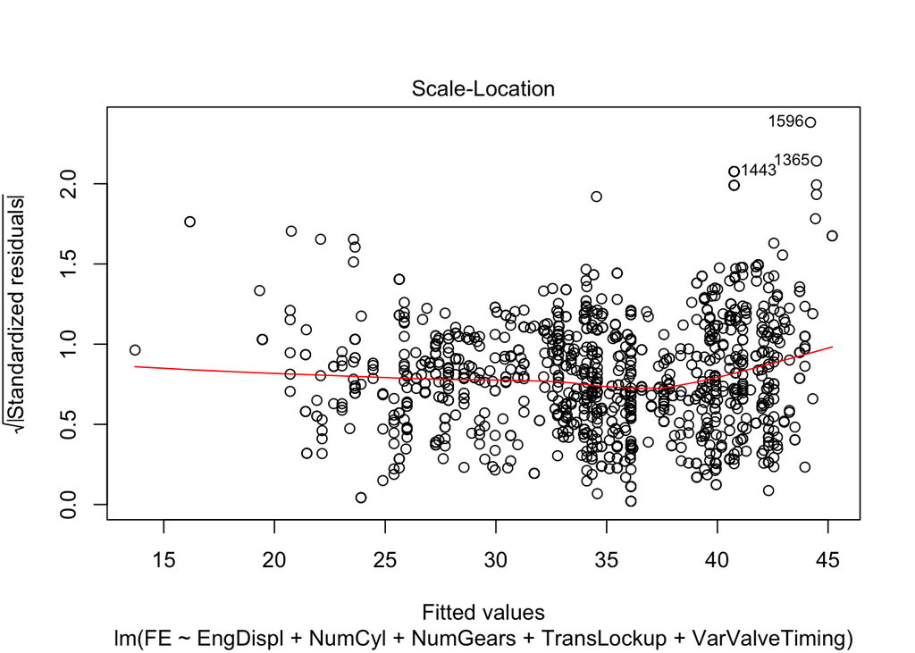

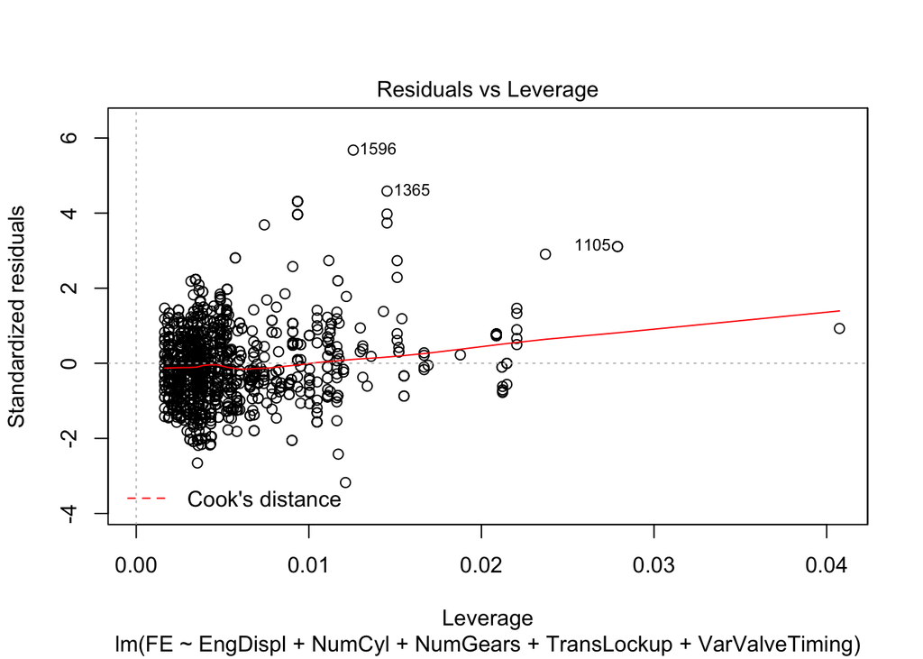

```r
# Diagnostic plots
plot(lmsmall)
```

Comment: In this unit, we’ve only learned how to interpret the first three of these plots. The first plot shows some curvature, so we might be missing a squared term in one of the predictors; in the $q-q$ plot, the standardized residuals show some departure from Normality (plotting a histogram would also reinforce this); and in the third plot, there is some (slight) evidence that variability increases. All in all, we would search for an alternative model to the one fitted here.

5. Regardless of your comments and analysis in d., your boss wants you to produce predictions of fuel efficiency for 2011 model-year vehicles. Calculate those predictions, produce an appropriate plot comparing predictions and actual values, and calculate the RMSEP. You do *not* have to put the value of RMSEP on the plot. Comment on any patterns you see in your plot. (5 marks)

```r
# Calculate predictions
FEpred <- predict(lmsmall, newdata = Cars2011)
```

```r
# Calculate RMSEP
RMSEP <- sqrt(sum((FEpred - Cars2011$FE)^2)/length(FEpred))
RMSEP
```

```
[1] 5.019626
```

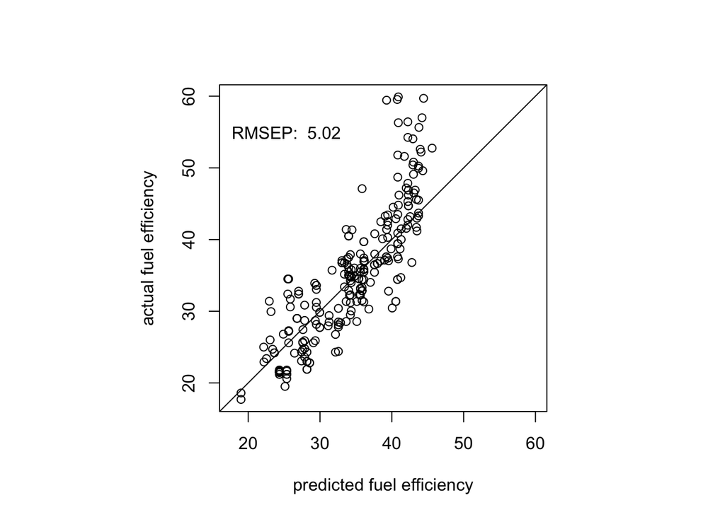

```r
# Appropriate plot
Range <- range(c(Cars2011$FE, FEpred))
par(pty = "s")
plot(Cars2011$FE ~ FEpred, xlab = "predicted fuel efficiency", ylab = "actual fuel efficiency",
    xlim = Range, ylim = Range)
abline(0, 1)
# Not required
text(min(Range), max(Range) - 5, paste("RMSEP: ", round(RMSEP, 2)), adj = 0)
```

Comments: The curvature we saw in the diagnostic plot above manifests itself here in the plot of actual fuel efficiency for 2011 vehicles against the corresponding predicted value.